신록예찬's 블로그

# (노트) Pytorch Linear Regression - 방법1

미완성

Aug 3, 2021 • 신록예찬 • 3 min read

파이토치 딥러닝

- Import
- Data
- 학습이란?
- 파라메터를 학습을 하는 방법
- Initial value
- One iteration
- Learn (=estimate $\hat{\bf W}$)
- Animation
- 로지스틱 모형

### Import

```python
import torch
import numpy as np
import matplotlib.pyplot as plt
```

### Data

`-` model: $y_i=w_0+w_1x_i+\epsilon_i=2.5+4x_i+\epsilon_i , \quad \mbox{for } i=1,2,\dots,n $

`-` model: ${\bf y} = {\bf X} {\bf W} +\boldsymbol{\epsilon}$

- ${\bf y}=\begin{bmatrix} y_1 \\ y_2 \\ \dots \\ y_n\end{bmatrix}, \quad {\bf X} = \begin{bmatrix} 1 & x_1 \\ 1 & x_2 \\ .. \\ 1 & x_n \end{bmatrix}, \quad {\bf W}= \begin{bmatrix} 2.5 \\ 4 \end{bmatrix} $

```python
n = 100
ones = torch.ones(n)
x,_ = torch.randn(n).sort()
X = torch.vstack([ones,x]).T
W = torch.tensor([2.5,4])
ϵ = torch.randn(n)*0.5
```

```python
torch.manual_seed(43052)
y=X@W+ϵ
ytrue=X@W
```

- ${\bf y}={\bf X W}+\boldsymbol{\epsilon}$
- ${\bf y}_{\tt ture}={\bf X W}$

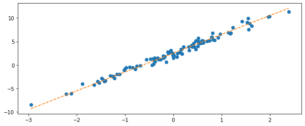

```python
plt.plot(x,y,'o')
plt.plot(x,ytrue,'--')
```

### 학습이란?

`-` 파란점만 주어졌다고 했을때, 주황색점들을 추론하는것. 좀 더 정확하게 말하면 given data로 $\begin{bmatrix} \hat{w}_0 \\ \hat{w}_1\end{bmatrix}$를 최대한 $\begin{bmatrix} 2.5 \\ 4 \end{bmatrix}$와 가깝게 찾는것.

- Given data: $\big\{(1,x_i),y_i\big\}_{i=1}^{n}$
- Parameter: $\begin{bmatrix} w_0 \\ w_1\end{bmatrix}$
- Estimated parameter: $\begin{bmatrix} \hat{w}_0 \\ \hat{w}_1\end{bmatrix}$

`-` 모형을 학습한다 = 모형에 사용된 파라메터를 esimate 한다.

### 파라메터를 학습을 하는 방법

`-` 이론적으로 추론

`-` 컴퓨터의 반복계산을 이용하여 추론 (경사하강법)

### Initial value

```python
torch.manual_seed(2021)
What = torch.tensor([-5.,10.],requires_grad=True)
#What = torch.randn(2,requires_grad=True) # 아무거나 뿌림
```

```python
What
```

```
tensor([-5., 10.], requires_grad=True)
```

```python
yhat=X@What
```

```python
yhat
```

```
tensor([-34.5353, -27.1867, -26.1298, -23.8352, -21.4520, -20.7062, -20.3335,
        -19.8438, -19.6414, -19.3569, -19.1832, -19.1345, -18.0194, -17.6216,
        -17.4255, -17.1977, -16.6843, -16.1426, -15.2025, -15.0481, -14.7597,
        -14.0602, -13.3963, -12.9322, -12.6157, -11.8414, -10.6039,  -9.7694,
         -9.4508,  -9.1127,  -9.1012,  -9.0407,  -8.9317,  -8.7999,  -8.2877,
         -8.0106,  -7.6492,  -7.1018,  -7.0266,  -6.7730,  -6.4521,  -6.2038,
         -6.0421,  -5.6353,  -5.5525,  -5.4216,  -5.1043,  -5.0967,  -5.0206,
         -4.9405,  -4.2946,  -4.2021,  -3.5761,  -3.4263,  -3.3515,  -3.3200,
         -3.2503,  -2.8481,  -1.8519,  -1.7077,  -1.1772,  -1.1074,  -0.7720,
         -0.7275,  -0.3989,  -0.3536,   0.0838,   0.0930,   0.1355,   0.2565,
          0.2882,   0.4010,   0.5449,   0.7001,   0.8808,   1.0229,   1.0856,
          1.2696,   2.0041,   2.4534,   2.9234,   2.9778,   3.0956,   3.2386,
          3.5696,   4.2518,   4.7468,   6.4253,   6.7677,   6.9065,   7.2936,
          9.2140,  10.2562,  10.5332,  10.6189,  10.7752,  11.2255,  14.6842,
         14.9175,  18.8969], grad_fn=<MvBackward>)
```

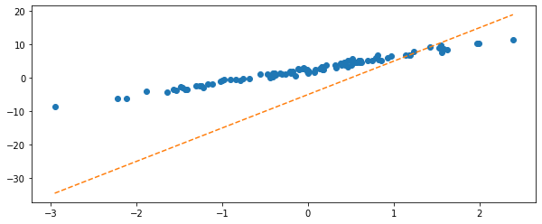

```python
plt.plot(x,y,'o')
plt.plot(x,yhat.data,'--')
```

### One iteration

```python
loss=torch.mean((y-yhat)**2) # np.mean() 하면 에러난다.
print(loss)
```

```
tensor(96.8086, grad_fn=<MeanBackward0>)
```

```python
loss.backward()
```

```python
What,What.data
```

```
(tensor([-5., 10.], requires_grad=True), tensor([-5., 10.]))
```

```python
What.grad.data
```

```
tensor([-15.3117,  12.7356])
```

`-` $loss(w_0,w_1)=(y-\hat{y})^\top (y-\hat{y})=(y-XW)^\top(y-XW)$

`-` $\frac{\partial}{\partial W}loss(w_0,w_1)= - 2X^\top y +2X^\top X W $

```python
-2 * X.T @ y + 2 * X.T @ X @ What
```

```
tensor([-1531.1736,  1273.5620], grad_fn=<AddBackward0>)
```

`-` 결과를 보니까 $loss(w_0,w_1)=\frac{1}{n}(y-\hat{y})^\top (y-\hat{y})=\frac{1}{n}(y-XW)^\top(y-XW)$ 인듯..

```python
learning_rate = 0.1
learning_rate * What.grad.data
```

```
tensor([-1.5312,  1.2736])
```

```python
What.data=What.data - learning_rate * What.grad.data #파라메터의 개선
What.data
```

```
tensor([-3.4688,  8.7264])
```

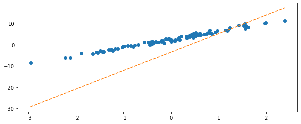

```python
yhat=X @ What
plt.plot(x,y,'o')
plt.plot(x,yhat.data,'--')
```

### Learn (=estimate $\hat{\bf W}$)

```python
losses=[]
yhats=[]
Whats=[]
```

```python
learning_rate = 0.1
for epoc in range(30):
    What.grad = None
    yhat=X@What
    loss=torch.mean((y-yhat)**2)
    loss.backward()
    What.data=What.data - learning_rate * What.grad.data
    losses.append(loss.item())
    Whats=Whats+[What.data.tolist()]
    yhats=yhats+[yhat.data.tolist()]
```

```python
What.data
```

```
tensor([2.5195, 3.8945])
```

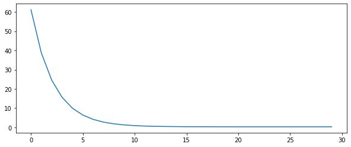

```python
plt.plot(losses)
```

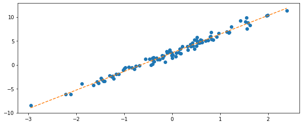

```python
plt.plot(x,y,'o')
plt.plot(x,yhats[29],'--')
```

### Animation

```python
plt.rcParams['figure.figsize'] = (10,4)
#plt.rcParams['figure.dpi'] = 80
#plt.rcParams['savefig.dpi'] = 80
plt.rcParams["animation.html"] = "jshtml"
```

```python
Whats[0][0]
```

```
-2.249298095703125
```

```python
np.arrange?
```

```
Object `np.arrange` not found.
```

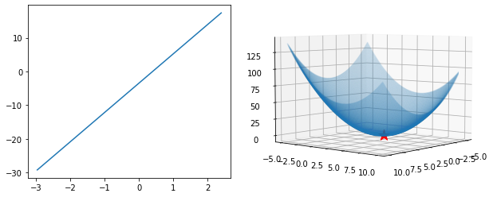

```python
fig = plt.figure()

# First subplot
ax1 = fig.add_subplot(1, 2, 1)
# Second subplot
ax2 = fig.add_subplot(1, 2, 2, projection='3d')

## ax1
ax1.plot(x,yhats[0])

## ax2
_w0 = np.arange(-5, 10, 0.1)
_w1 = np.arange(-5, 10, 0.1)
w1,w0 = np.meshgrid(_w1,_w0)
l=w0*0
for i in range(len(_w0)):
    for j in range(len(_w1)):
        l[i,j]=torch.mean((y-_w0[i]-_w1[j]*x)**2)

ax2.scatter(w0, w1, l, alpha=.1,s=1)
ax2.scatter(2.5,4,torch.mean((y-2.5-4*x)**2),s=200,c='red',marker='*')
ax2.azim = 40
ax2.dist = 8
ax2.elev = 5
```

```python
np.array(Whats)[0:1,0]
```

```
array([-2.2492981])
```

```python
from matplotlib import animation
from IPython.display import HTML

# Set up a figure twice as tall as it is wide
fig = plt.figure()

# First subplot
ax1 = fig.add_subplot(1, 2, 1)
# Second subplot
ax2 = fig.add_subplot(1, 2, 2, projection='3d')

## ax1
ax1.plot(x,y,'o')
line, = ax1.plot(x,yhats[0])
 ## ax2
_w0 = np.arange(-5, 10, 0.5)
_w1 = np.arange(-5, 10, 0.5)
w1,w0 = np.meshgrid(_w1,_w0)
l=w0*0
for i in range(len(_w0)):
    for j in range(len(_w1)):
        l[i,j]=torch.mean((y-_w0[i]-_w1[j]*x)**2)

ax2.plot_surface(w0, w1, l, rstride=1, cstride=1, color='b',alpha=0.35)
ax2.scatter(2.5,4,torch.mean((y-2.5-4*x)**2),s=200,color='red',marker='*')
ax2.scatter(np.array(Whats)[0,0],np.array(Whats)[0,1],losses[0],color='b')
ax2.azim = 40
ax2.dist = 8
ax2.elev = 5
#ax2.plot(Whats[0:2][0],Whats[0:2][1],torch.mean((y-Whats[0:2][0]-Whats[0:2][1]*x)**2), linestyle="dashed",linewidth=2,color="grey")

def animate(i):
    line.set_ydata(yhats[i])
    ax2.scatter(np.array(Whats)[i,0],np.array(Whats)[i,1],losses[i],color='grey')
    return line

ani = animation.FuncAnimation(fig, animate, frames=30)
plt.close()
ani
```

[figure not shown]

### 로지스틱 모형

```python
πi=torch.exp(X@W)/(torch.exp(X@W)+1)
```

```python
np.random.binomial(n=1,p=πi,size=100)
```

[output not shown]